# Examen Parcial 1

Laura Julià Melis

November 2, 2017

## PARTE A

1. Describe el diseño, la variable respuesta y los factores (di si es fijo o aleatorio, y número de niveles). Escribe la ecuación del modelo, con las posibles restricciones y suposiciones. (1 punto)

Se trata de un diseño de un factor (los tratamientos) totalmente aleatorizado.

$y_ij= \mu + {\alpha}_i + e_ij$

$j = 1, . . . , 5$ rèpliques (participants diabètics)

$e_ij ~ N(0, \sigma)$ independents

2. ¿Hay relación entre la dosis del fármaco y la variable respuesta? Justifica la respuesta y formula la hipótesis a contrastar. (1,5 puntos)

```r
y <- c(9.72,    9.88,   10.78,  10.04,  10.06, 12.26,   11.63,  10.77,  11.06,  11.18, 12.21,   11.78,  11.80,  11.66,  11.32, 11.49,   10.85,  9.62,   10.95,  10.36)
tract <- factor(rep(1:4, each=5))
model <- aov(y ~ tract)
summary(model)
```

```
##             Df Sum Sq Mean Sq F value   Pr(>F)
## tract        3  8.232   2.744   9.978 0.000601 ***
## Residuals   16  4.400   0.275
## ---
## Signif. codes:  0 '***' 0.001 '**' 0.01 '*' 0.05 '.' 0.1 ' ' 1
```

Hay diferencias significativas entre los tratamientos ya que el p-valor de la tabla ANOVA es 0.000601 < 0.05.

```r
library(agricolae)
HSD.test(model, "tract", console=TRUE)
```

```
##
## Study: model ~ "tract"
##
## HSD Test for y
##
## Mean Square Error:  0.27501
##
## tract,  means
##
##        y       std r   Min   Max
## 1 10.096 0.4063004 5  9.72 10.78
## 2 11.380 0.5812487 5 10.77 12.26
## 3 11.754 0.3193431 5 11.32 12.21
## 4 10.654 0.7036547 5  9.62 11.49
##
## Alpha: 0.05 ; DF Error: 16
## Critical Value of Studentized Range: 4.046093
##
## Minimun Significant Difference: 0.9489102
##
## Treatments with the same letter are not significantly different.
##
##        y groups
## 3 11.754      a
## 2 11.380     ab
## 4 10.654     bc
## 1 10.096      c
```

## PARTE B

1. ¿Puede decirse que la emisión de partícules es diferente en función de las condiciones de conducción (arranque-y-paro o autopista)? Para responder la pregunta:

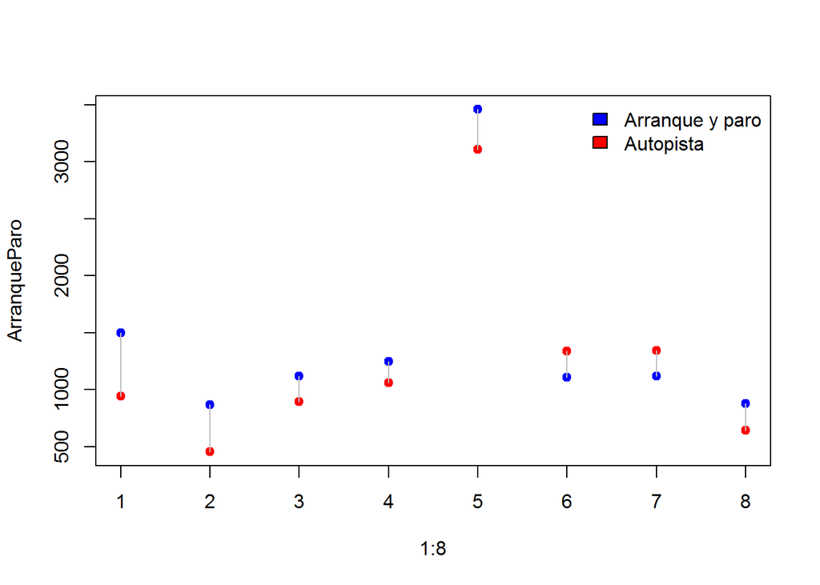

```r
ArranqueParo <- c(1500, 870,    1120,   1250,   3460,   1110,   1120,   880)
Autopista <- c(941, 456,    893,    1060,   3107,   1339,   1346,   644)

# Gráfica descriptiva:
plot(1:8, ArranqueParo , ylim=range(c(ArranqueParo , Autopista)), pch=19, col="blue")
points(1:8,Autopista, pch=19, col=2)
segments(1:8, ArranqueParo , 1:8, Autopista, col="grey")
legend("topright", c("Arranque y paro", "Autopista"), fill=c("blue", "red"), bty="n")
```

```r
# Contraste de hipótesis:
t.test(ArranqueParo, Autopista, paired=TRUE)
```

```
##
##  Paired t-test
##
## data:  ArranqueParo and Autopista
## t = 1.8965, df = 7, p-value = 0.09971
## alternative hypothesis: true difference in means is not equal to 0
## 95 percent confidence interval:
##  -47.01698 428.01698
## sample estimates:
## mean of the differences
##                   190.5
```

En el gráfico se observa que la mayoría de puntos azules (Arranque y paro) se encuentran por encima de los rojos (Autopista). Así pues, parece que la emisión de partículas es mayor en esas primeras condiciones.

El valor del estadístico de prueba es t=1.8965, una t-student con n-1=7 grados de libertad. El p valor obtenido es 0.09971, por lo que es mayor que 0.05 y no se rechaza la hipótesis de que la emisión de partícules es igual, en función de las condiciones de conducción (arranque-y-paro o autopista).

2. Supongamos ahora que los 4 primeros coches (del 1 al 4) incorporan un catalitzador para reducir la emisión de partícules. ¿Puede decirse que - POR AUTOPISTA - los que llevan catalitzador emiten menos partículas? Para responder la pregunta:

```r
dd <- as.data.frame(ArranqueParo)
dd$Autopista <- Autopista
dd$Catalizador <- rep(c(1,0), each=4)

head(dd)
```

```
##   ArranqueParo Autopista Catalizador
## 1         1500       941           1
## 2          870       456           1
## 3         1120       893           1
## 4         1250      1060           1
## 5         3460      3107           0
## 6         1110      1339           0
```

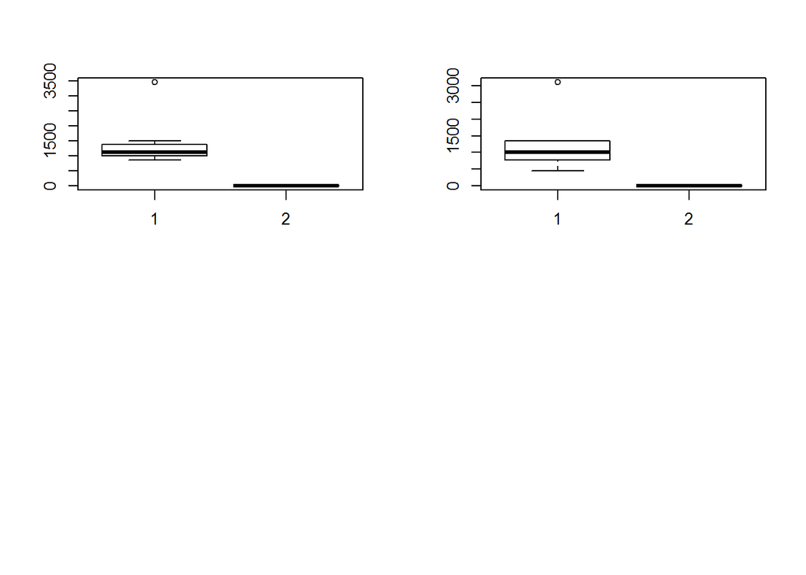

```r
# Gráfica descriptiva:
par(mfrow=c(2,2))
boxplot(dd$ArranqueParo, dd$Catalizador)
boxplot(dd$Autopista, dd$Catalizador)

# Contrase de hipótesis:
```

[output not shown]

[output not shown]